# Heat Trees

### Build the difference table again, this time for the differential heat tree matrix

```r
obj$data$diff_table$wilcox_p_value <- p.adjust(obj$data$diff_table$wilcox_p_value, method = "fdr") #run an fdr adjustment on the wilcox p-values
obj$data$diff_table$log2_median_ratio[obj$data$diff_table$wilcox_p_value > 0.05] <- 0 #set ratios where the difference between groups is not significantly different to 0
obj$data$diff_table <- compare_groups(obj, dataset = "tax_abund", cols = obj$data$sample_data$sample_id, groups = obj$data$sample_data$Region) #build the difference table
```

[output not shown]

```r
obj$data$diff_table #confirm it worked
```

| taxon_id | treatment_1 | treatment_2 | log2_median_ratio | median_diff | mean_diff | wilcox_p_value |
| --- | --- | --- | --- | --- | --- | --- |
| ab | Lower Keys | Upper Keys | 0.000000000 | 0.000000e+00 | 0.000000e+00 | 1.0000000000 |
| ac | Lower Keys | Upper Keys | 0.156283835 | 1.022620e+01 | 7.737756e+00 | 0.0020708950 |
| ad | Lower Keys | Upper Keys | -6.159203347 | -1.036748e+01 | -8.021673e+00 | 0.0013010466 |
| ae | Lower Keys | Upper Keys | 1.000027192 | 7.539204e-03 | 6.125979e-02 | 0.3025885590 |
| af | Lower Keys | Upper Keys | 1.115937306 | 1.319694e-02 | 7.927974e-02 | 0.0814596451 |
| ag | Lower Keys | Upper Keys | 0.000000000 | 0.000000e+00 | -1.858689e-02 | 0.4085649818 |
| ah | Lower Keys | Upper Keys | 0.000000000 | 0.000000e+00 | 5.345208e-02 | 0.1019862670 |
| ai | Lower Keys | Upper Keys | 0.000000000 | 0.000000e+00 | 6.771543e-04 | 0.5097316756 |
| aj | Lower Keys | Upper Keys | Inf | 7.540767e-03 | 2.444023e-02 | 0.1310989032 |
| ak | Lower Keys | Upper Keys | 0.000000000 | 0.000000e+00 | 6.366801e-02 | 0.6244344880 |

[output cut: 990 more lines]

## Heat tree matrix

### by region

What is a heat tree matrix? A heat tree matrix is a series of differential heat trees in a matrix format. They are used when you are trying to compare more than 2 groups (i.e. our 3 regions).

What goes in? -> your taxmap object

What goes out? -> a heat tree matrix -> a pdf of the heat tree matrix

How do you read the colors in a heat tree matrix? A taxon colored brown is more abundant in the group colored brown and a taxon colored blue-green is more abundant in the group colored blue-green

```
Use of "dataset" is depreciated. Use "data" instead.
```

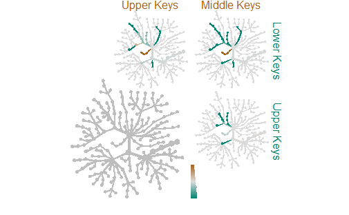

```r
set.seed(1) #this makes the plot appear the same each time it is run
obj %>% #set heat_tree_matrix() to run with your taxmap object
          filter_taxa(grepl(pattern = "^[a-zA-Z]+$", taxon_names),reassign_obs = FALSE) %>% #remove the taxa with odd names like “Ellin329” and “BD7−3” since they do not effect the outcome of our plots besides taking up space for bacteria with negligible abundances; you should be sure to check that they are negligible in your data before using this line!
            heat_tree_matrix(dataset = "diff_table", #select the dataset within taxmap to the difference table
                   node_label = taxon_names, #set the node labels to the taxonomy information
                   node_size = n_obs, #set the node size to scale with the differential abundance ratios
                   node_color = log2_median_ratio, #set the node color to scale with the differential abundance ratios
                   node_label_size = 0.035, #set the node label size
                   repel_labels = TRUE, #stops the labels from overlapping
                   node_color_trans = "linear", #set the color transformation to linear
                   node_color_interval = c(-3, 3), #set the node color interval to match the ratio range
                   edge_color_interval = c(-3, 3), #set the edge color interval to match the ratio range
                   node_color_range = diverging_palette(), #set the node color palette
                   node_size_axis_label = "OTU count", #title the node size legend
                   node_color_axis_label = "Log 2 ratio of median counts", #title the node color legend
                   layout = "da", initial_layout = "re", #set the layout algorithms
                   key_size = 0.67, #set the size of the key tree (aka the legend tree that shows the taxonomy information)
                   seed = 2, #random seed used to make the graphs
                   output_file = "differential_heat_tree.pdf") #set the name to save the heat tree as a file (along the same lines as ggsave)
```